# Course ML - Project

Klod Kolaro

November 8, 2018

Six young health participants were asked to perform one set of 10 repetitions of the Unilateral Dumbbell Biceps Curl in five different fashions: exactly according to the specification (Class A), throwing the elbows to the front (Class B), lifting the dumbbell only halfway (Class C), lowering the dumbbell only halfway (Class D) and throwing the hips to the front (Class E). Class A corresponds to the specified execution of the exercise, while the other 4 classes correspond to common mistakes. The exercises were performed by six male participants aged between 20-28 years, with little weight lifting experience.  
The goal of your project is to predict the manner in which they did the exercise. This is the “classe” variable in the training set.

```r
options(warn=-1)
library(caTools)
library(caret)
```

```r
library(ggplot2)
library(dplyr)
library(sqldf)
```

# Data import

```r
getwd()
```

```
## [1] "C:/Users/kkolaro/Desktop/Private/ucenje/Coursera/machine learning/project"
```

```r
setwd("C:/Users/kkolaro/Desktop/Private/ucenje/Coursera/machine learning/project")
data_training<-read.csv("pml-training.csv",na.strings = c("NA","#DIV/0!", " "))
dim(data_training)
```

```
## [1] 19622   160
```

```r
data_test<-read.csv("pml-testing.csv",na.strings = c("NA","#DIV/0!", " "))
set.seed(12345)
```

# Exploratory analysis

```r
unique(data_training$classe)
```

```
## [1] A B C D E
## Levels: A B C D E
```

```r
unique(data_training$user_name)
```

```
## [1] carlitos pedro    adelmo   charles  eurico   jeremy
## Levels: adelmo carlitos charles eurico jeremy pedro
```

```r
summary(data_training$classe)
```

```
##    A    B    C    D    E
## 5580 3797 3422 3216 3607
```

```r
# Total number of exercises per classe

sqldf("select count(classe) as Total_number,classe from data_training group by classe order by Total_number desc")
```

```
##   Total_number classe
## 1         5580      A
## 2         3797      B
## 3         3607      E
## 4         3422      C
## 5         3216      D
```

```r
summary(data_training[,c("classe")])
```

```
##    A    B    C    D    E
## 5580 3797 3422 3216 3607
```

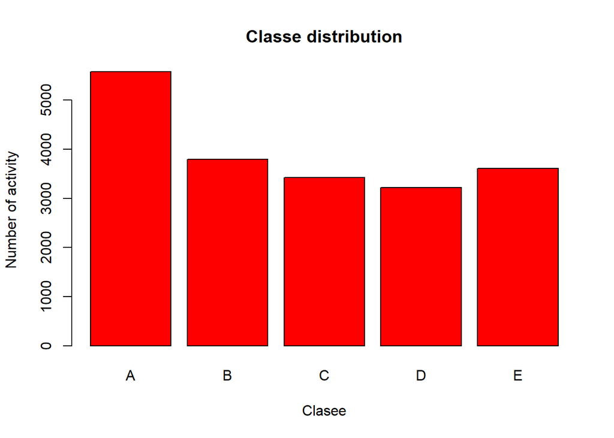

```r
barplot(table(data_training$classe), main = "Classe distribution", beside=FALSE,xlab="Clasee",ylab="Number of activity",col="red")
```

```r
# Total number of exercises  per user

sqldf("select count(classe) as Total_number,user_name from data_training group by user_name order by Total_number desc")
```

```
##   Total_number user_name
## 1         3892    adelmo
## 2         3536   charles
## 3         3402    jeremy
## 4         3112  carlitos
## 5         3070    eurico
## 6         2610     pedro
```

```r
# Participants per classes

sqldf("select count(classe),user_name,classe from data_training group by user_name,classe")
```

```
##    count(classe) user_name classe
## 1           1165    adelmo      A
## 2            776    adelmo      B
## 3            750    adelmo      C
## 4            515    adelmo      D
## 5            686    adelmo      E
## 6            834  carlitos      A
## 7            690  carlitos      B
## 8            493  carlitos      C
## 9            486  carlitos      D
## 10           609  carlitos      E
## 11           899   charles      A
## 12           745   charles      B
## 13           539   charles      C
## 14           642   charles      D
```

[output cut: 16 more lines]

```r
usr_class<-prop.table(table(data_training$classe,data_training$user_name),2)#procentage of user perclass
print(usr_class)
```

```
##
##        adelmo  carlitos   charles    eurico    jeremy     pedro
##   A 0.2993320 0.2679949 0.2542421 0.2817590 0.3459730 0.2452107
##   B 0.1993834 0.2217224 0.2106900 0.1928339 0.1437390 0.1934866
##   C 0.1927030 0.1584190 0.1524321 0.1592834 0.1916520 0.1911877
##   D 0.1323227 0.1561697 0.1815611 0.1895765 0.1534392 0.1796935
##   E 0.1762590 0.1956941 0.2010747 0.1765472 0.1651969 0.1904215
```

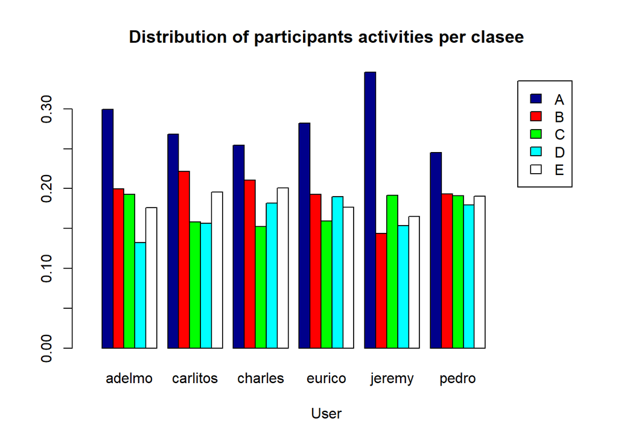

```r
barplot(usr_class, main="Distribution of participants activities per clasee",xlab = "User",legend = row.names(usr_class),beside=TRUE,col=c("darkblue","red","green","cyan","white"),,xlim=c(0, ncol(usr_class) + 37))
```

```r
# Classes per participants

class_usr<-prop.table(table(data_training$user_name,data_training$classe),2)#class per user
print(class_usr)
```

```
##
##                    A         B         C         D         E
##   adelmo   0.2087814 0.2043719 0.2191701 0.1601368 0.1901857
##   carlitos 0.1494624 0.1817224 0.1440678 0.1511194 0.1688384
##   charles  0.1611111 0.1962075 0.1575102 0.1996269 0.1971167
##   eurico   0.1550179 0.1559126 0.1428989 0.1809701 0.1502634
##   jeremy   0.2109319 0.1287859 0.1905319 0.1623134 0.1558082
##   pedro    0.1146953 0.1329997 0.1458212 0.1458333 0.1377876
```

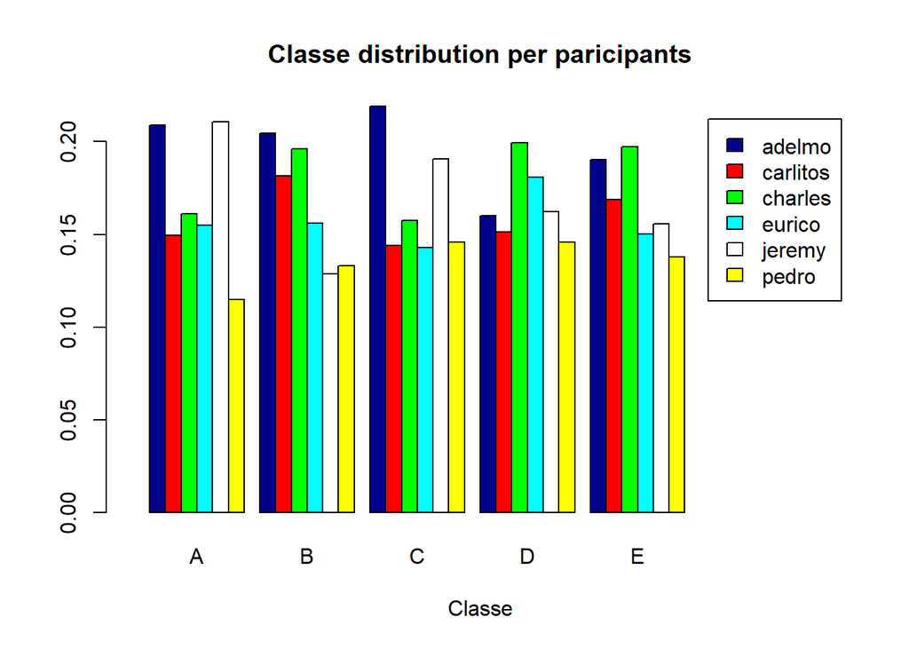

```r
barplot(class_usr, main="Classe distribution per paricipants",xlab = "Classe",legend = row.names(class_usr),beside=TRUE,col=c("darkblue","red","green","cyan","white","yellow"),xlim=c(0, ncol(class_usr) + 39))
```

## Key findings:

Max number of activities is of classe A - 5580 and min of classe D - 3216 Out of total number of A classe ,Jeremy contribute with 21,1% ,and Pedro only 11,4% The highest % of class A had Jeremy 34,59% and the lowest Pedro 24,5%

# Data cleansing & transformation

```r
data_training_NA<-sapply(data_training, function(x)all(!is.na(x)))
data_test_NA<-sapply(data_test, function(x)all(!is.na(x)))

data_training<-data_training[,data_training_NA]
data_test<-data_test[,data_test_NA]

data_training<-subset(data_training, select = -c(X,user_name))
data_test<-subset(data_test, select = -c(X,user_name))

data_training<-data_training[,!(grepl("window|timestamp", colnames(data_training)))]
data_test<-data_test[,!(grepl("window|timestamp", colnames(data_test)))]
```

# Modeling

```r
# Creating test and training datasets from data_training set and  Cross validation

inTrain<-createDataPartition(data_training$classe,p=0.7,list = FALSE)
training<-data_training[inTrain,]
testing<-data_training[-inTrain,]

# RF-willuse a Random forests a method well-suited to problems with a relatively small number of
# observations with a large number of feature variables.

controlPar<-trainControl(method = "cv",number=5)
Random_model<-train(classe~.,data=training,method="rf", trControl=controlPar,ntree=50)

Random_model
```

```
## Random Forest
##
## 13737 samples
##    52 predictor
##     5 classes: 'A', 'B', 'C', 'D', 'E'
##
## No pre-processing
## Resampling: Cross-Validated (5 fold)
## Summary of sample sizes: 10990, 10989, 10990, 10989, 10990
## Resampling results across tuning parameters:
##
##   mtry  Accuracy   Kappa
##    2    0.9878428  0.9846203
##   27    0.9885710  0.9855418
##   52    0.9826743  0.9780796
##
## Accuracy was used to select the optimal model using the largest value.
## The final value used for the model was mtry = 27.
```

```r
prediction<-predict(Random_model,testing)
table(predictions=prediction, actual=testing$classe)
```

```
##            actual
## predictions    A    B    C    D    E
##           A 1669   10    0    0    0
##           B    5 1122    7    0    0
##           C    0    7 1016   13    1
##           D    0    0    3  950    7
##           E    0    0    0    1 1074
```

# Predicting 20 different test cases

```r
prediction_test<-predict(Random_model,data_test)
print(prediction_test)
```

```
##  [1] B A B A A E D B A A B C B A E E A B B B
## Levels: A B C D E
```

```r
options(warn=0)
```